# Example Unit 3 Project: Credit Scores and Age

## *Scott Adams, Promotable*

## Overview

### *Problem Statement*

Analyzing credit trends is important for gaining a better understanding of the financial security of a population. Indeed, possessing a good credit score provides access to financing for major investments such as cars, housing, and education. However, a credit profile takes time to build and a short credit history is one factor that can have a negative impact on an individual’s credit score.

### *Proposed Test*

This analysis tested the hypothesis that credit scores are, on average, higher among older individuals.

### *Measurable Outcome*

Using the Churn-Modelling data, I examined whether age is associated with credit score. More specifically, I tested the hypothesis that being older will be associated with higher credit scores, on average.

## Setup

### *Import Libraries*

Remember that Python is modular. This means that the functionality available by default in a Python session is limited. We need to explicitly import the libraries that contain the functions and data structures that are needed for a given project.

```python
import pandas as pd
import os
import numpy as np
from sklearn import datasets, linear_model
from sklearn import metrics
from matplotlib import pyplot as plt
import statsmodels.api as sm
```

### Read and Explore Data

I recommend setting a working directory for your project so you do not have to include the full path when reading in raw data using the `read_csv` function from Pandas. Using the `os` library, let's set the desired working directory and print out the directory once it is set to make sure the correct direcotry is now the working directory.

```python
path = "/Users/scottadams/Google_Drive/Promotable/Nov18/projects/"
os.chdir(path)
os.getcwd()
```

```
'/Users/scottadams/Google_Drive/Promotable/Nov18/projects'
```

Read in the Churn-Modelling csv data, specifying that the first row is a header (i.e., the first row contains column names). Here, we are assigning the raw csv data to a new Pandas dataframe object called `churn`. You can think of a dataframe as a collolary to a SQL table or spreadsheetm where data is structured in rows and columns. For more information on dataframes and data structures in Pandas check out the [Pandas documentation](https://pandas.pydata.org/pandas-docs/stable/dsintro.html).

Then, look at the first 5 rows just as a check that the data were properly imported.

```python
churn = pd.read_csv("Churn-Modelling.csv", header = 0)
churn.head(5)
```

|  | RowNumber | CustomerId | Surname | CreditScore | Geography | Gender | Age | Tenure | Balance | NumOfProducts | HasCrCard | IsActiveMember | EstimatedSalary | Exited |
| --- | --- | --- | --- | --- | --- | --- | --- | --- | --- | --- | --- | --- | --- | --- |
| 0 | 1 | 15634602 | Hargrave | 619 | France | Female | 42 | 2 | 0.00 | 1 | 1 | 1 | 101348.88 | 1 |
| 1 | 2 | 15647311 | Hill | 608 | Spain | Female | 41 | 1 | 83807.86 | 1 | 0 | 1 | 112542.58 | 0 |
| 2 | 3 | 15619304 | Onio | 502 | France | Female | 42 | 8 | 159660.80 | 3 | 1 | 0 | 113931.57 | 1 |
| 3 | 4 | 15701354 | Boni | 699 | France | Female | 39 | 1 | 0.00 | 2 | 0 | 0 | 93826.63 | 0 |
| 4 | 5 | 15737888 | Mitchell | 850 | Spain | Female | 43 | 2 | 125510.82 | 1 | 1 | 1 | 79084.10 | 0 |

### Dealing with Missing Data

This section is just an example for dealing with missing data. The first code block below will run a check to see if there are any missing (i.e., `NULL`) values in the dataframe.

```python
churn.isnull().values.any()
```

```
False
```

The `False` output indicates that there are no missing records in the dataframe. Nevertheless, for the purposes of illustrating how to handle missing data I am going to set a random set of cells to missing. Each cell has a 10% chance of being set to missing and this chance of missingness is independent of the values in any other cells. In the end, about 10% of all cells will be missing (i.e., these cells will have a value of `NaN`, which means "not a number").

```python
churn = churn.mask(np.random.random(churn.shape) < .1)
print("Number of missing cells: {}, ".format(churn.isnull().sum().sum()),
      "% of cells with missing data: {}" .format(((churn.isnull().sum().sum())/(churn.shape[0]*churn.shape[1])*100)))
```

```
Number of missing cells: 13965,  % of cells with missing data: 9.975000000000001
```

```python
churn.head()
```

|  | RowNumber | CustomerId | Surname | CreditScore | Geography | Gender | Age | Tenure | Balance | NumOfProducts | HasCrCard | IsActiveMember | EstimatedSalary | Exited |
| --- | --- | --- | --- | --- | --- | --- | --- | --- | --- | --- | --- | --- | --- | --- |
| 0 | 1.0 | 15634602.0 | Hargrave | 619.0 | France | Female | 42.0 | 2.0 | 0.00 | 1.0 | 1.0 | 1.0 | 101348.88 | 1.0 |
| 1 | 2.0 | 15647311.0 | Hill | 608.0 | Spain | Female | 41.0 | 1.0 | 83807.86 | 1.0 | 0.0 | 1.0 | 112542.58 | 0.0 |
| 2 | NaN | 15619304.0 | Onio | 502.0 | France | Female | 42.0 | 8.0 | 159660.80 | 3.0 | 1.0 | 0.0 | 113931.57 | 1.0 |
| 3 | 4.0 | 15701354.0 | Boni | 699.0 | France | Female | 39.0 | 1.0 | 0.00 | 2.0 | 0.0 | 0.0 | 93826.63 | NaN |
| 4 | 5.0 | 15737888.0 | NaN | 850.0 | Spain | NaN | 43.0 | 2.0 | 125510.82 | 1.0 | NaN | 1.0 | 79084.10 | 0.0 |

If data are missing completely at random (MCAR), meaning that an observation's probability of having missing data on a given variable does not depend on the true value of the variable in question or the values of any other variables. In this case, dropping observations with missing data on any variables that will be used in the analyses would result in a loss of data, but would not bias the data. The uncommented syntax below will drop observations with any missing data on `Age` or `CreditScore`. The commented code shows an alternative approach, which is to set missing values on a variable to the variable's mean. Though this approach is used by some, I recommend not using it for a number of reasons, including the fact that imputing missing data with the variable's mean artifically minimizes the measure's variance. Additionally, the mean that is imputed on to missing observations is the variable's mean **excluding missing data**! Thus, if observations with missing data on the variable in question have systematically different values on the variable in question compared to observations with valid data on said variable, bias will be introducted.

```python
churn = churn[~np.isnan(churn[['Age', 'CreditScore']]).any(axis=1)]
#churn['Age'].fillna(churn['Age'].mean(), inplace=True)
#churn['CreditScore'].fillna(churn['CreditScore'].mean(), inplace=True)
churn.isnull().sum()
```

```
RowNumber          815
CustomerId         809
Surname            785
CreditScore          0
Geography          831
Gender             822
Age                  0
Tenure             842
Balance            796
NumOfProducts      841
HasCrCard          768
IsActiveMember     796
EstimatedSalary    833
Exited             795
dtype: int64
```

The output above shows that Age and CreditScore have no missing data. Keep in mind, however, that we are now working with feer observations. Wheras the original Churn-Modelling data had 10,000 observations, the new Churn-Modelling data is smaller after excluding cases with missing data on `Age` and `CreditScore`.

```python
len(churn)
```

```
8134
```

## Analyses

### *Exploratory Data Analyses*

Descriptive statistics and correlations for the variables of interest are provided below.

```python
churn[['Age', 'CreditScore']].describe()
```

|  | Age | CreditScore |
| --- | --- | --- |
| count | 8134.000000 | 8134.000000 |
| mean | 38.957463 | 650.627121 |
| std | 10.538748 | 96.361879 |
| min | 18.000000 | 350.000000 |
| 25% | 32.000000 | 583.000000 |
| 50% | 37.000000 | 652.000000 |
| 75% | 44.000000 | 717.000000 |
| max | 92.000000 | 850.000000 |

```python
churn.loc[:, ['Age', 'CreditScore']].corr()
```

|  | Age | CreditScore |
| --- | --- | --- |
| Age | 1.000000 | -0.005135 |
| CreditScore | -0.005135 | 1.000000 |

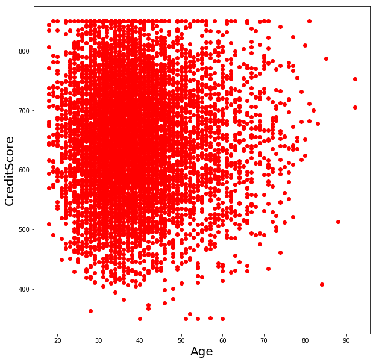

```python
plt.figure(figsize=(10, 10))
ax = plt.axes()
ax.scatter(churn['Age'], churn['CreditScore'],color='r')
ax.set_xlabel('Age', size = 20)
ax.set_ylabel('CreditScore', size = 20)
plt.show()
```

Contrary to the initial hypothesis, age and credit score exhibit a very weak negative correlation. This relationship is explored further in a linear regression model in the next section.

### *Regression Analysis*

```python
# Place features and target into an array
X = np.c_[churn.loc[:, ['Age']]]
y = np.c_[churn.loc[:, 'CreditScore']]

lm = linear_model.LinearRegression()
lm.fit(X, y)
yhat = lm.predict(X)
residual = y - yhat
sresidual = residual/residual.std()
r2 = lm.score(X, y)
mse = metrics.mean_squared_error(y, lm.predict(X))
```

```python
print(
" MODEL OUTPUT \n",
" \n",
"====================================\n",
"Coefficient(s): {} \n" .format(lm.coef_), "Intercept: {} \n" .format(lm.intercept_), "R-Squared: {} \n" .format(r2), "MSE: {} \n" .format(mse),
"====================================\n"
)
```

```
 MODEL OUTPUT

 ====================================
 Coefficient(s): [[-0.04695155]]
 Intercept: [652.45623383]
 R-Squared: 2.636739868588922e-05
 MSE: 9284.225325102196
 ====================================
```

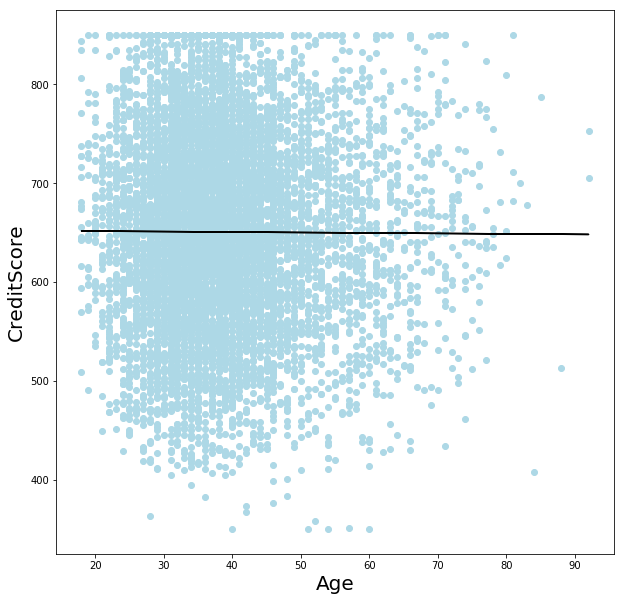

```python
plt.figure(figsize=(10, 10))
ax = plt.axes()
ax.scatter(X, y,color='lightblue')
ax.plot(X, lm.predict(X),color='black')
ax.set_xlabel('Age', size = 20)
ax.set_ylabel('CreditScore', size = 20)
plt.show()
```

Below, the `where` function from the Numpy library is used to create three mutually exclusive variables, also referred to as "dummy variables." `np.where` is just a conditional statement where the first argument in parentheses provided the condition to be evaluated, the second argument is the value to be returned if the condition is `True`, and the third argument is the value to be returned if the condition is `False`. For example, `churn['age18_29'] = np.where(churn['Age'].between(18, 29), 1, 0)` creates a new column in the `churn` dataframe called `age18_29` which takes a value of 1 when `Age` is between 18 and 29, and a value of 0 otherwise. Since these new age ategories are coded as `0` and `1`, the mean of each age category will be the proportion of cases coded as a `1` on the variable, and the sum of all three proportion will equal 1.

```python
churn['age18_29'] = np.where(churn['Age'].between(18, 29), 1, 0)
churn['age30_64'] = np.where(churn['Age'].between(30, 64), 1, 0)
churn['age65+'] = np.where(churn['Age'] >= 65, 1, 0)

churn.loc[:, ['age18_29','age30_64','age65+']].mean()
```

```
age18_29    0.163880
age30_64    0.807598
age65+      0.028522
dtype: float64
```

```python
churn.loc[:, ['age18_29','age30_64','age65+']].mean()
```

```
age18_29    0.163880
age30_64    0.807598
age65+      0.028522
dtype: float64
```

```python
# Place features and target into an array, leave one of the age category dummy variables out to serve as base category.
X_d = np.c_[churn.loc[:, ['age18_29', 'age30_64']]]


lmd = linear_model.LinearRegression()
lmd.fit(X_d, y)
yhat_d = lmd.predict(X_d)
residual_d = y - yhat_d
sresidual_d = residual_d/residual_d.std()
r2_d = lmd.score(X_d, y)
mse_d = metrics.mean_squared_error(y, lmd.predict(X_d))

print(
" MODEL OUTPUT \n",
" \n",
"====================================\n",
"Coefficient(s): {} \n" .format(lmd.coef_), "Intercept: {} \n" .format(lmd.intercept_), "R-Squared: {} \n" .format(r2_d), "MSE: {} \n" .format(mse_d),
"====================================\n"
)
```

```
 MODEL OUTPUT

 ====================================
 Coefficient(s): [[-10.31785964  -9.8750794 ]]
 Intercept: [660.29310345]
 R-Squared: 0.0002983280586105197
 MSE: 9281.70031447793
 ====================================
```

```python
f = plt.figure(figsize=(7, 5))
ax = f.add_subplot(111)
ax.barv(residual, bins=50)
plt.axvline(residual.mean(), color='k', linestyle='dashed', linewidth=3)
ax.set_xlabel('Residual')
ax.set_ylabel('Frequency')
f.show()
```

[output not shown]

```python
print("Predicted Credit Score:, \n",
      "Age 18-29: {}, \n" .format(round(lmd.predict(np.array([[1, 0]])).item(), 2) ),
      "Age 30-64: {}, \n" .format(round(lmd.predict(np.array([[0, 1]])).item(), 2) ),
      "Age 65+: {}"  .format(round(lmd.predict(np.array([[0, 0]])).item(), 2)) )
```

```
Predicted Credit Score:,
 Age 18-29: 649.98,
 Age 30-64: 650.42,
 Age 65+: 660.29
```

Note that in this case, the predicted values from our regression model with the age dummy variables are the simply the mean Credit Score for each age category.

```python
print(round(churn.loc[churn['age18_29'] ==1, 'CreditScore'].mean(), 2),
      round(churn.loc[churn['age30_64'] ==1, 'CreditScore'].mean(), 2),
      round(churn.loc[churn['age65+'] ==1, 'CreditScore'].mean(), 2))
```

```
649.98 650.42 660.29
```

Even more, the regression coefficient for each age group is just the mean for the age group of interest minus the reference group, `age65+` in this case.

```python
print(churn.loc[churn['age18_29'] ==1, 'CreditScore'].mean() - churn.loc[churn['age65+'] ==1, 'CreditScore'].mean(),
     churn.loc[churn['age30_64'] ==1, 'CreditScore'].mean() - churn.loc[churn['age65+'] ==1, 'CreditScore'].mean())
```

```
-10.317859637323068 -9.875079395908642
```

So, why go through all this trouble, and code, to run a linear regression model with dummy variables when you could get predicted values by examining the mean outcome by each group? Great question! In the case of a simple linear regression model with one predictor (or in this case one set of dummy variables), there is little benefit to conducting a linear regression to get predicted values. However, the linear regression model does providethe $R^2$ value, which is a nice metric of model fit. In this example, the mean credit score is higher for older adults, but the mean credit score among older adults is only about 10 points higher than either of the younger age groups. Taking this result alongside the small $R^2$ provides a stronger case that age may not be the best predictor of credit scores.

## Conclusion

The linear regression results using age groups as predictors of credit score, as opposed to the continuous age value, is consistent with the initial hypothesis that older individuals tend to have better credit scores than younger individuals. However, the $R^2$ value for the model with the dummy variable predictors was still very low, indicating that age is not a very strong predictor of credit score. Thus, the relationship between age and credit score is not a very meaningful relationship based on the Churn-Modeling data.